# PixelMonitoring_Workflow

**ROI counters and mosaic workflow over a set of Laue images (2D map)**

Same core workflow (`LaueTools.scripts.workflows.ROICountersWorkflow`) as in:

- **GUI**: PeakSearchGUI, tab *Mosaic & Monitor* (*Computing / Run on*)
- **command line**: `python -m LaueTools.scripts.workflowlauncher submit config.json --resource magnifix --wait`
- **this notebook**

Images are processed in parallel, in this kernel, in a background process on this machine, or in a SLURM job on an ESRF partition.

Counters (in each ROI of each image): `mosaic` (ROI pixel intensities), `mean`, `max`, `ptp`, `sum`, `pixelval` (ROI center pixel), `XYmax` (position of max), `XYcentroid` (center of mass above ROI minimum), `fit` (2D gaussian fit, see `FIT_COLUMNS`).

```python
# %matplotlib widget   # for jupyterlab interactive plots
import os
import numpy as np
import matplotlib.pyplot as plt

import LaueTools.logfile_reader as iohdf5
import LaueTools.scripts.workflows as wf
import LaueTools.scripts.workflowlauncher as WL
import LaueTools.scripts.roicountersplot as RCP
```

# 0 - Parameters

(cell tagged `parameters`)

```python
# experiment and scan (BLISS hdf5 logfile of a dataset)
CCDLabel = 'EIGER_4MCdTe'
h5logfile = '/data/visitor/<proposal>/bm32/<date>/RAW_DATA/<sample>/<dataset>/<dataset>.h5'
scan_idx = 0  # index of scan in logfile.dfallscans

# ROIs centers (X, Y detector pixels), one of:
#   - list of (X, Y): [[1177, 1803]] or [[X1, Y1], [X2, Y2], ...]
#   - peak list file .dat, .cor or .fit: '/path/to/peaks.cor'  (or {'file': '/path/to/peaks.cor', 'maxnbrois': 50})
#   - automatic grid: {'grid': 200} or {'grid': (stepX, stepY), 'xlim': (xmin, xmax), 'ylim': (ymin, ymax)}
roicenters = '/data/visitor/<proposal>/bm32/<date>/PROCESSED_DATA/<sample>/<dataset>/scan0001/corfiles/eiger4m_1857.cor'
# ROI half sizes along X and Y
boxsize_X, boxsize_Y = 8, 6

# computation: in this kernel (3a) and/or as a job (3b)
RUN_IN_KERNEL = True
RECOMPUTE = False  # 3a: compute again even if results of same parameters exist
resource = 'magnifix3'  # 'local', 'magnifix', 'magnifix3' (3 nodes, images shared between nodes), 'nice-hpc7', ... (see WL.COMPUTING_RESOURCES)
nbcpus = None  # 3a and 'local'; per node for SLURM (None: all cpus of nodes, e.g. magnifix3)

# output folder: 'image' (folder of images, default), 'mirror' (PROCESSED_DATA mirror folder) or path of a folder
OUTPUT_FOLDER_MODE = 'image'
```

# 1 - Scan parameters from BLISS hdf5 logfile

```python
logfile = iohdf5.H5file(h5logfile, CCDLabel)
logfile.getscans(verbose=0)
logfile.dfallscans[['fullcommand', 'imagefolder']]
```

|  | fullcommand | imagefolder |
| --- | --- | --- |
| 0 | fscan2d xps 1.37415 0.002 131 yps -7.602 0.002... | /data/visitor//bm32//RAW_DATA/ |

```python
d = logfile.build_dict_scan(scan_idx, verbose=False)
print(d['fullcommand'], '\nmap dimensions (fast, slow):', d['mapdimensions'], '\nimages folder:', d['folder'])
```

```
scan dictionary created for key 0 :)
fscan2d xps 1.37415 0.002 131 yps -7.602 0.002 231 1 1.00004
map dimensions (fast, slow): (231, 131)
images folder: /data/visitor/<proposal>/bm32/<date>/RAW_DATA/<sample>/<dataset>/scan0001
```

# 2 - ROIs and counters

`roicenters` (cell 0) is converted to the list of (X, Y) ROIs centers by `wf.resolve_roicenters()`:

- list of (X, Y) detector pixels (one ROI as in the GUI, or many ROIs)
- peak list file `.dat`, `.cor` or `.fit` (X, Y of peaks of all grains, rounded to pixel), e.g. from a peak search; `{'file': path, 'maxnbrois': n}` keeps the n first peaks of the file
- automatic grid `{'grid': step}` or `{'grid': (stepX, stepY), 'xlim': (xmin, xmax), 'ylim': (ymin, ymax)}` (default: whole detector frame)

Many ROIs with `mosaic` counter: results size is nb images x nb ROIs x ROI size (float32).

```python
params = dict(d)
params['boxsize_X'], params['boxsize_Y'] = boxsize_X, boxsize_Y
# list of (X, Y) from list, peak list file or grid
params['roicenters'] = wf.resolve_roicenters(roicenters, CCDLabel, boxsize_X, boxsize_Y)
if not isinstance(roicenters, (list, tuple, np.ndarray)):
    params['roicenters_source'] = roicenters  # file path or grid dict (kept in results params)
print(f"{len(params['roicenters'])} ROI(s), first ones: {params['roicenters'][:5]}")
params['counters'] = ['max', 'mean', 'fit'] #['mosaic', 'mean', 'max', 'ptp', 'XYcentroid', 'fit']
params['fitparameters'] = {'peaksizeStart': 2.}

print('possible counters:', list(wf.ROI_COUNTERS))
```

```
351 ROI(s), first ones: [[623, 1424], [352, 1593], [454, 1520], [1832, 1439], [662, 1405]]
possible counters: ['mosaic', 'mean', 'max', 'ptp', 'sum', 'pixelval', 'XYmax', 'XYcentroid', 'fit']
```

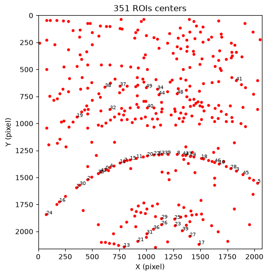

```python
# ROIs centers on detector frame (index of first ROIs)
framedim = wf.DictLT.dict_CCD[CCDLabel][0]  # (nb lines, nb columns)
XY = np.array(params['roicenters'])
fig, ax = plt.subplots(figsize=(6, 6))
ax.scatter(XY[:, 0], XY[:, 1], s=10, c='r')
for k, (x, y) in enumerate(XY[:50]):
    ax.annotate(str(k), (x, y), fontsize=7)
ax.set_xlim(0, framedim[1])
ax.set_ylim(framedim[0], 0)
ax.set_aspect('equal')
ax.set_xlabel('X (pixel)')
ax.set_ylabel('Y (pixel)')
ax.set_title(f'{len(XY)} ROIs centers')
plt.show()
```

# 3a - Compute in this kernel (blocking)

If results were already computed with the same parameters, they are loaded from the results file (`RECOMPUTE = True` to compute again). Results with missing images (scan not completed) are recomputed.

```python
# local !  whatever resource='local' or not !
if RUN_IN_KERNEL:
    # results loaded if already computed with the same parameters (results file roicounters_<hash>.h5
    # in output folder, see OUTPUT_FOLDER_MODE), else computed and saved
    cachefolder = WL.output_folder(params['folder'], OUTPUT_FOLDER_MODE)
    results = wf.run_roi_counters_cached(params, cachefolder, nb_cpus=nbcpus, progressbar=True,
                                         recompute=RECOMPUTE)
```

[output not shown]

```
[interactive widget (ipywidgets)]
```

```
ROI counters collected in 388.1 s
results saved in /data/visitor/<proposal>/bm32/<date>/RAW_DATA/<sample>/<dataset>/scan0001/roicounters_d6aea39f89d9.h5
```

# 3b - OR launch a job on this machine or on a SLURM partition (as the GUI does)

Results (.h5), configuration, log and status files are written in the output folder: folder of images (default), mirror folder in PROCESSED_DATA, or any folder (`OUTPUT_FOLDER_MODE`, same choice as in the GUI). If the folder is not writable, the PROCESSED_DATA mirror folder is used. For SLURM, `ssh {submit host}` must work without password if SLURM is not available on this machine.

```python
print('computing resources:', list(WL.COMPUTING_RESOURCES))

outputfolder = WL.output_folder(params['folder'], OUTPUT_FOLDER_MODE)
# results file name from ROIs: first ROI center, peak list file name or grid
source = params.get('roicenters_source')
if source is None:
    tag = 'X%d_Y%d' % tuple(params['roicenters'][0])
elif isinstance(source, dict) and 'grid' in source:
    tag = 'grid%d' % len(params['roicenters'])
else:
    tag = os.path.splitext(os.path.basename(source['file'] if isinstance(source, dict) else source))[0]
output = os.path.join(outputfolder, f'roicounters_{tag}.h5')

config = WL.make_config(params, output)
job = WL.launch(config, resource=resource, nbcpus=nbcpus)
```

```
computing resources: ['local', 'magnifix', 'magnifix3', 'ub20', 'nice-hpc7', 'nice-hpc8', 'nice-hpc6']
```

[output not shown]

```python
job.wait()
results = job.results()
```

```
[interactive widget (ipywidgets)]
```

```python
# equivalent command line (job configuration file already written)
print(f"python -m LaueTools.scripts.workflowlauncher submit {job.files['config']} --resource {resource} --wait")
```

# 4 - Plots

Maps are displayed with the y motor (yech, yps, ...) vertical, whatever the fast and slow axes. Mouse hovering on a map gives image index and value.

Zoom kept while browsing, hovering and clicking need an interactive matplotlib backend: uncomment `%matplotlib widget` in the first code cell (package `ipympl`). With inline figures, the browser redraws the whole figure.

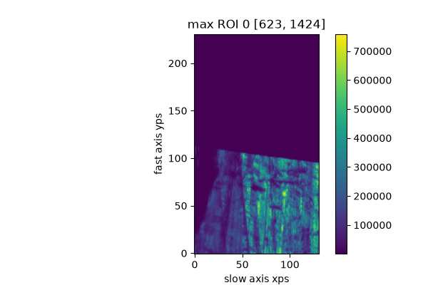

```python
# single map: 1 counter of 1 ROI
iroi = 0  # index of ROI (in params['roicenters'])
counter, column = 'max', 0  # column: index or name of value, e.g. 'fit', 'X' (see RCP.counter_columns('fit'))

display2D = RCP.MapDisplay(results)  # y motor vertical
values = RCP.counter_values(results, counter, column)[:, iroi]
fig, ax = plt.subplots(figsize=(6, 4))
im = display2D.imshow(ax, values)  # hovering: image index and value
ax.set_title(f"{counter} ROI {iroi} {results['params']['roicenters'][iroi]}")
ax.set_xlabel(display2D.xlabel)
ax.set_ylabel(display2D.ylabel)
fig.colorbar(im, ax=ax)
plt.show()
```

```python
if 'mosaic' in results:
    mosaic = wf.arrange_mosaic2D(results['mosaic'][:, iroi], results['params']['mapdimensions'])['singleimage']
    fig, ax = plt.subplots(figsize=(8, 8))
    ax.imshow(mosaic, origin='lower', vmax=np.nanpercentile(mosaic, 99.5))
    ax.set_title('mosaic of ROI %d centered on %s' % (iroi, results['params']['roicenters'][iroi]))
    plt.show()
```

## Maps of a counter for several ROIs

Zoom is shared by all maps; each map has its own contrast (percentiles of its values).

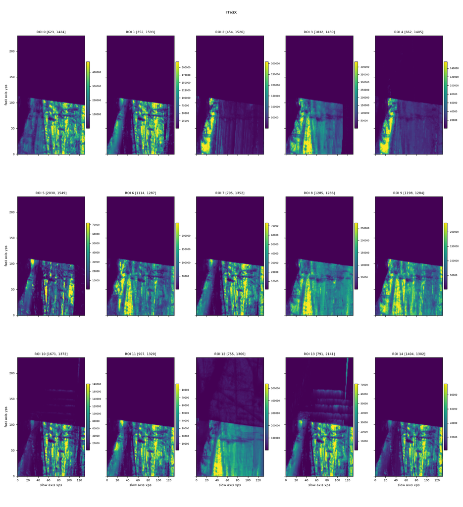

```python
fig.clear('All')
roiindices = range(0, 15)  # e.g. [0, 3, 7] or range(0, len(results['params']['roicenters']), 10)
fig, axes = RCP.plot_counter_maps(results, 'max', roiindices=roiindices, column=0, nbcols=5,
                                  percentiles=(1, 99))
```

## Browser of maps

- left: map of current ROI. ROI index (slider or play), counter and value, contrast (percentiles), log10. The zoom is kept when browsing. Mouse hovering: image index, map position and value. Click: image index and file
- right: ROIs centers on detector (peak list of section 2). Click close to a ROI center: map of this ROI
- (if `mosaic` counter was computed) pixel intensities of the ROI in the clicked image

Mouse hovering and clicks need `%matplotlib widget` (package `ipympl` in the kernel environment).

```python
%matplotlib widget
browser = RCP.CounterMapBrowser(results, counter='max', iroi=0)
browser.show()
```

```
[interactive widget (ipywidgets)]
```